# AS2019455

M.M.S.B.Munasinghe

10/5/2022

## **01.Introduction**

The COVID-19 pandemic, also known as the corona virus pandemic, is an ongoing global pandemic. It spread all over the world and affect the people health as well as their economic.In this report we try to talk about how COVID-19 affect the country Belarus.

## 1.1.Brief Introduction about Belarus

Belarus is officially the Republic of Belarus and a landlocked country in Eastern Europe.Covering an area of 207,600 square kilometres (80,200 sq mi) and with a population of 9.2 million, Belarus is the 13th-largest and the 20th-most populous country in Europe. The country has a hemiboreal climate and is administratively divided into seven regions. Minsk is the capital and largest city.

Belarus has a population of 9.4 million people (in 2022). Spoken languages are Belarusian (official) 24%, but 70% speak Russian (official), there are small Polish- and Ukrainian-speaking minorities. Ethnic Belarusians, who speak a language closely related to Russian and Ukrainian, make up more than three-quarters of the population.Belarus is a developing country, ranking 60th in the Human Development Index.

Belarus has trade relations with over 180 countries. The main trading partners are Russia, which accounts for about 45% of Belarusian exports and 55% of imports, and the EU countries, which account for 25% of exports and 20% of imports.

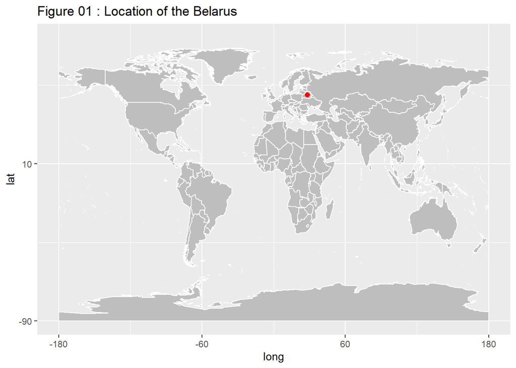

# 1.2.Geography of Belarus

It is bordered by Russia to the east and northeast, Ukraine to the south, Poland to the west, and Lithuania and Latvia to the northwest.

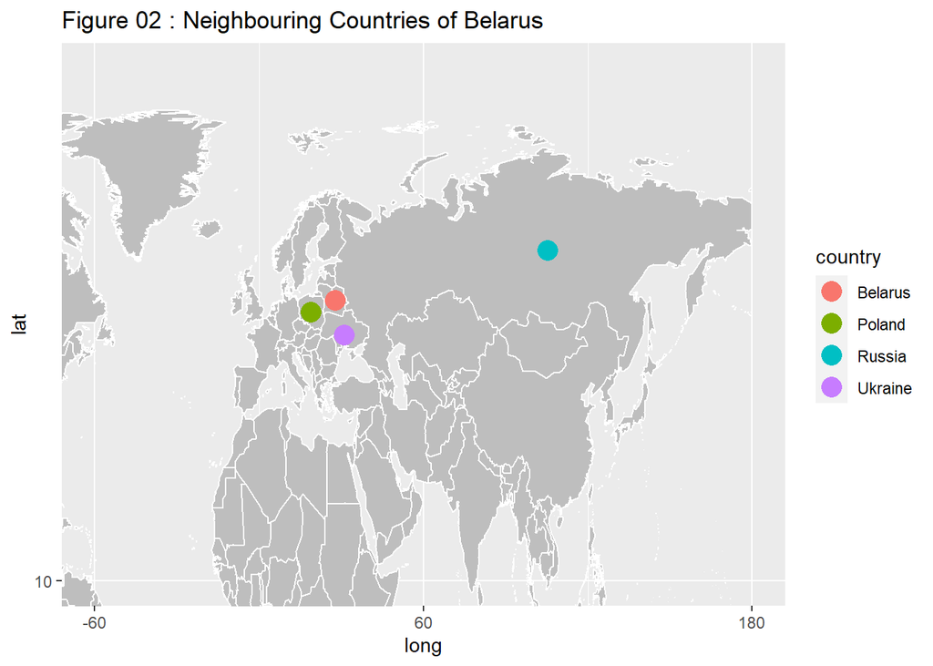

## **03.Exploratory Data Analysis**

The COVID-19 pandemic in Belarus is part of the ongoing worldwide pandemic of coronavirus disease 2019 (COVID-19). The virus was confirmed to have spread to Belarus, when the first case of COVID-19 in the country was registered in Minsk on 28 February 2020.According to the World Health Organization reports, a total of 15,582,410 vaccine doses gave to the people until 7th of October 2022.

In this dataset contains the daily summary of COVID-19 cases according to the type of confirmed, death, and recovered data in Belarus.

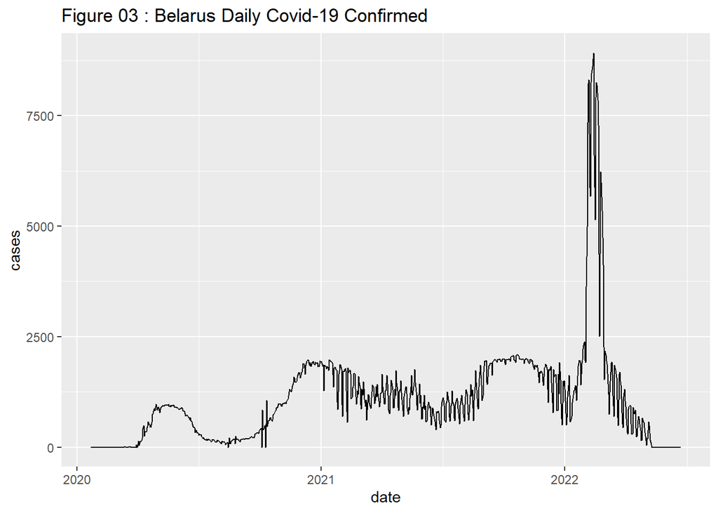

In figure 03 shows the yearly variation of confirmed coronavirus cases in Belarus.According to this plot we can say from year 2020 to 2022 there is nearly same variation of the data and there is no significant increase or decrease was shown but the beginning of the year 2022 confirmed daily corona cases are increasing rapidly.Middle of the year 2022 corona cases are decreasing gradually and now number of cases come close to zero.

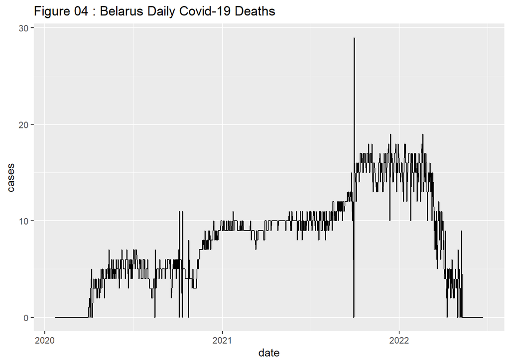

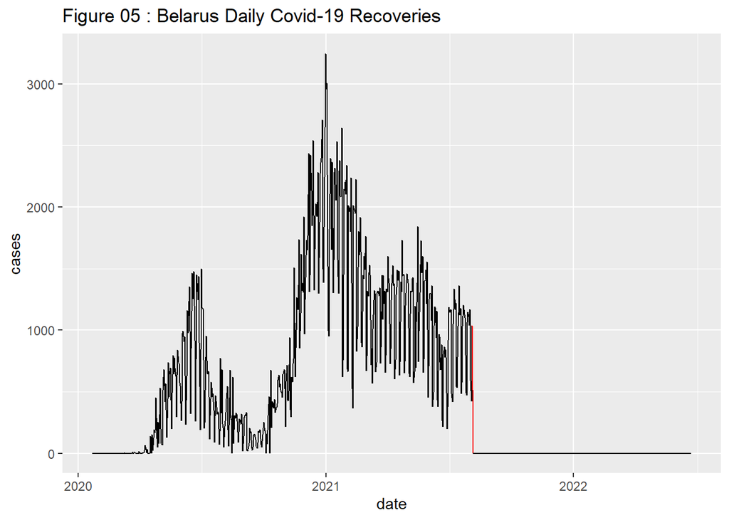

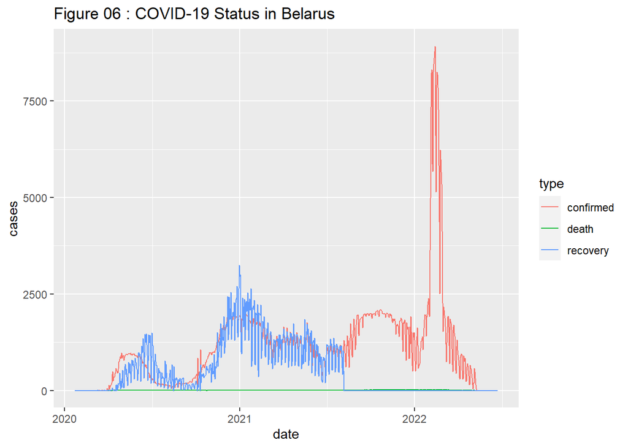

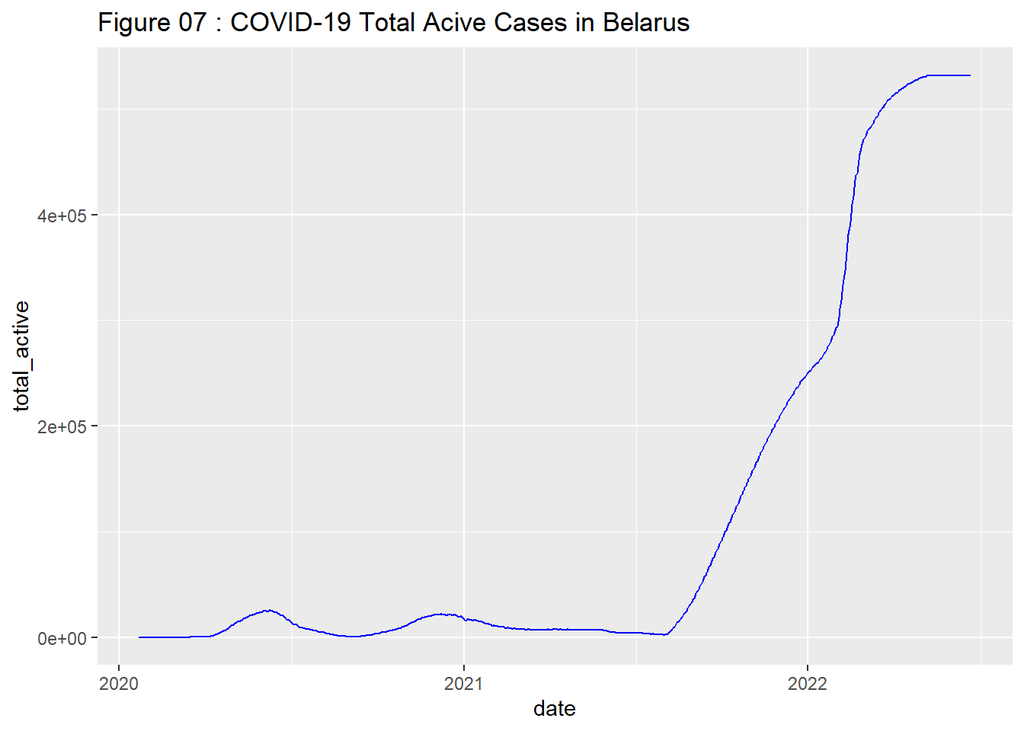

Figure 07 shows the cumulative sums of the active cases in Belarus.

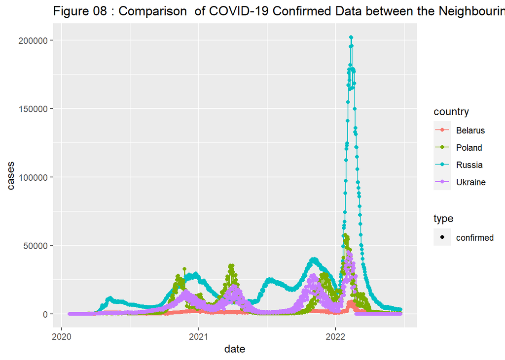

When considering the confirmed cases of these four countries Belarus cases in range 0 to 50000 always because Belarus population is small than comparing other countries.According to the plot we can say Poland and Ukraine affect the pandemic in same way.Beginning of the year 2022 these countries shows same variation and same time points the cases are increasing suddenly.Highest cases were reported in Russia in that period.

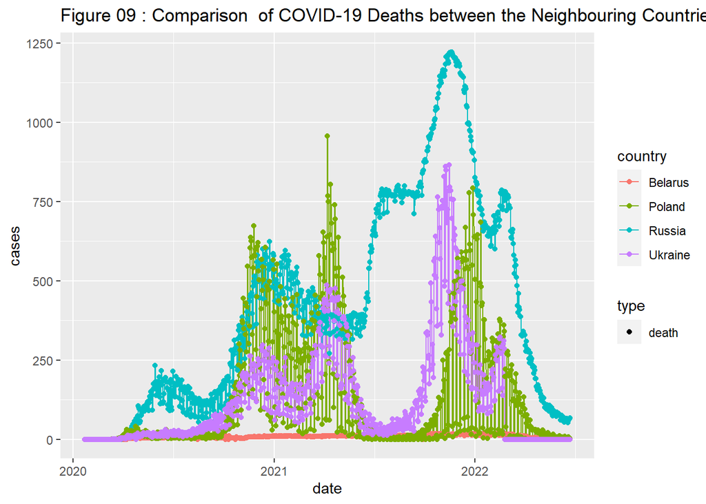

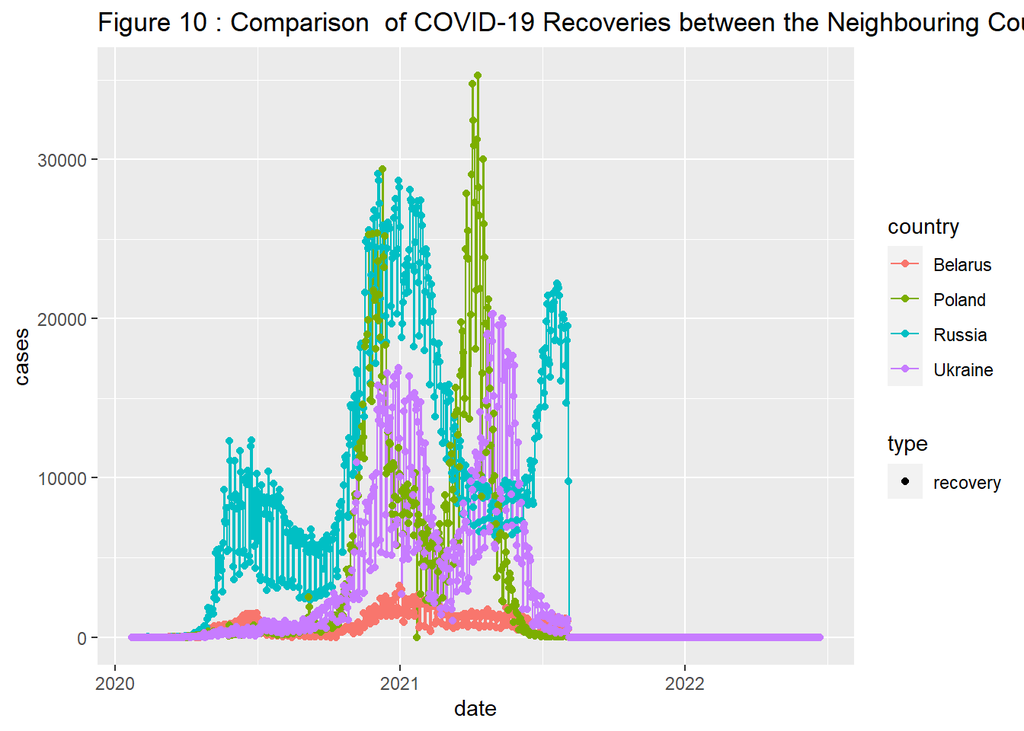

## **04.Conclusions and Discussion**

- According to this analysis we can conclude the government of Belarus control the pandemic situation in a favorable way.They always kept the daily death cases is very low value and Both confirmed and death cases are close to zero now in Belarus.
- If the government continue to implement their health polices and regulations they can get rid of the COVID-19 at the end of the year 2022.

## **05.References**

https://en.wikipedia.org/wiki/Belarus

https://hellor.netlify.app/

https://covid19.who.int/region/euro/country/by